# Task 2

## Diego Kozlowski

```python
import pandas as pd
import numpy as np
from sklearn.preprocessing import OneHotEncoder, LabelEncoder
from sklearn.model_selection import train_test_split
from sklearn.metrics import accuracy_score, classification_report, confusion_matrix
from sklearn.svm import SVC
from sklearn.ensemble import GradientBoostingClassifier, RandomForestClassifier
import missingno as msno
```

```python
main_df = pd.read_csv('data/task2-main_train.csv')
additional_df = pd.read_csv('data/task2-additional.csv')
```

```python
main_df.describe()
```

|  | SK_ID_CURR | TARGET | CNT_CHILDREN | AMT_INCOME_TOTAL | AMT_CREDIT | REGION_POPULATION_RELATIVE | DAYS_BIRTH | DAYS_EMPLOYED | DAYS_REGISTRATION | DAYS_ID_PUBLISH | FLAG_MOBIL | FLAG_EMP_PHONE | FLAG_WORK_PHONE | FLAG_CONT_MOBILE | FLAG_PHONE | FLAG_EMAIL | REGION_RATING_CLIENT | REGION_RATING_CLIENT_W_CITY | HOUR_APPR_PROCESS_START | REG_REGION_NOT_LIVE_REGION | REG_REGION_NOT_WORK_REGION | LIVE_REGION_NOT_WORK_REGION | REG_CITY_NOT_LIVE_CITY | REG_CITY_NOT_WORK_CITY | LIVE_CITY_NOT_WORK_CITY | FLAG_DOCUMENT_2 | FLAG_DOCUMENT_3 | FLAG_DOCUMENT_4 | FLAG_DOCUMENT_5 | … |
| --- | --- | --- | --- | --- | --- | --- | --- | --- | --- | --- | --- | --- | --- | --- | --- | --- | --- | --- | --- | --- | --- | --- | --- | --- | --- | --- | --- | --- | --- | --- |
| count | 80000.000000 | 80000.000000 | 80000.000000 | 8.000000e+04 | 8.000000e+04 | 80000.000000 | 80000.000000 | 80000.000000 | 80000.000000 | 80000.00000 | 80000.000000 | 80000.000000 | 80000.000000 | 80000.000000 | 80000.000000 | 80000.000000 | 80000.000000 | 80000.000000 | 80000.000000 | 80000.000000 | 80000.000000 | 80000.000000 | 80000.000000 | 80000.000000 | 80000.000000 | 80000.000000 | 80000.000000 | 80000.000000 | 80000.000000 | … |
| mean | 278104.707063 | 0.082525 | 0.417450 | 1.684795e+05 | 5.981715e+05 | 0.020832 | -16039.900738 | 64298.115925 | -4981.408213 | -2992.28250 | 0.999988 | 0.818600 | 0.199362 | 0.997950 | 0.280438 | 0.056438 | 2.053987 | 2.032862 | 12.076375 | 0.014175 | 0.050350 | 0.040575 | 0.076575 | 0.230538 | 0.179462 | 0.000050 | 0.711000 | 0.000087 | 0.014550 | … |
| std | 102987.110897 | 0.275165 | 0.718465 | 1.145367e+05 | 4.046058e+05 | 0.013838 | 4362.872130 | 141678.038791 | 3518.264797 | 1508.16642 | 0.003536 | 0.385352 | 0.399524 | 0.045231 | 0.449216 | 0.230766 | 0.509069 | 0.502554 | 3.259873 | 0.118213 | 0.218667 | 0.197305 | 0.265918 | 0.421180 | 0.383742 | 0.007071 | 0.453301 | 0.009354 | 0.119743 | … |
| min | 100007.000000 | 0.000000 | 0.000000 | 2.700000e+04 | 4.500000e+04 | 0.000533 | -25197.000000 | -17583.000000 | -23738.000000 | -6337.00000 | 0.000000 | 0.000000 | 0.000000 | 0.000000 | 0.000000 | 0.000000 | 1.000000 | 1.000000 | 0.000000 | 0.000000 | 0.000000 | 0.000000 | 0.000000 | 0.000000 | 0.000000 | 0.000000 | 0.000000 | 0.000000 | 0.000000 | … |
| 25% | 188704.000000 | 0.000000 | 0.000000 | 1.125000e+05 | 2.700000e+05 | 0.010006 | -19682.250000 | -2771.000000 | -7491.000000 | -4296.00000 | 1.000000 | 1.000000 | 0.000000 | 1.000000 | 0.000000 | 0.000000 | 2.000000 | 2.000000 | 10.000000 | 0.000000 | 0.000000 | 0.000000 | 0.000000 | 0.000000 | 0.000000 | 0.000000 | 0.000000 | 0.000000 | 0.000000 | … |
| 50% | 277720.500000 | 0.000000 | 0.000000 | 1.462500e+05 | 5.099220e+05 | 0.018850 | -15763.000000 | -1200.000000 | -4504.000000 | -3246.50000 | 1.000000 | 1.000000 | 0.000000 | 1.000000 | 0.000000 | 0.000000 | 2.000000 | 2.000000 | 12.000000 | 0.000000 | 0.000000 | 0.000000 | 0.000000 | 0.000000 | 0.000000 | 0.000000 | 1.000000 | 0.000000 | 0.000000 | … |
| 75% | 367623.250000 | 0.000000 | 1.000000 | 2.025000e+05 | 8.086500e+05 | 0.028663 | -12420.000000 | -277.000000 | -2009.000000 | -1716.75000 | 1.000000 | 1.000000 | 0.000000 | 1.000000 | 1.000000 | 0.000000 | 2.000000 | 2.000000 | 14.000000 | 0.000000 | 0.000000 | 0.000000 | 0.000000 | 0.000000 | 0.000000 | 0.000000 | 1.000000 | 0.000000 | 0.000000 | … |
| max | 456254.000000 | 1.000000 | 10.000000 | 1.350000e+07 | 4.050000e+06 | 0.072508 | -7673.000000 | 365243.000000 | 0.000000 | 0.00000 | 1.000000 | 1.000000 | 1.000000 | 1.000000 | 1.000000 | 1.000000 | 3.000000 | 3.000000 | 23.000000 | 1.000000 | 1.000000 | 1.000000 | 1.000000 | 1.000000 | 1.000000 | 1.000000 | 1.000000 | 1.000000 | 1.000000 | … |

```python
main_df.isna().sum().sum()
```

```
0
```

```python
additional_df.sample(2)
```

|  | SK_ID_CURR | SK_ID_BUREAU | CREDIT_ACTIVE | CREDIT_CURRENCY | DAYS_CREDIT | CREDIT_DAY_OVERDUE | DAYS_CREDIT_ENDDATE | DAYS_ENDDATE_FACT | AMT_CREDIT_MAX_OVERDUE | CNT_CREDIT_PROLONG | AMT_CREDIT_SUM | AMT_CREDIT_SUM_DEBT | AMT_CREDIT_SUM_LIMIT | AMT_CREDIT_SUM_OVERDUE | CREDIT_TYPE | DAYS_CREDIT_UPDATE | AMT_ANNUITY |
| --- | --- | --- | --- | --- | --- | --- | --- | --- | --- | --- | --- | --- | --- | --- | --- | --- | --- |
| 113657 | 162647 | 5745844 | Closed | currency 1 | -588 | 0 | -223.0 | -345.0 | 0.0 | 0 | 65430.0 | 0.0 | 0.0 | 0.0 | Consumer credit | -342 | NaN |
| 145509 | 437599 | 5487848 | Closed | currency 1 | -2551 | 0 | -1959.0 | -1642.0 | 0.0 | 1 | 67500.0 | 0.0 | 0.0 | 0.0 | Credit card | -1642 | NaN |

```python
additional_df.isna().sum().sum()
```

```
1115070
```

Additional data has many NaNs

```python
print(additional_df.shape)
print(additional_df.dropna().shape)
```

```
(476974, 17)
(12920, 17)
```

If I drop the NaN's I loose too much information

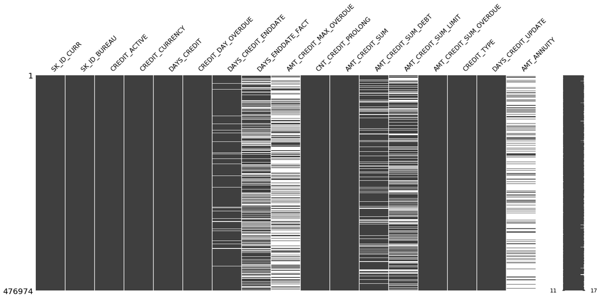

```python
msno.matrix(additional_df)
```

It looks that when the credit is Active, DAYS_ENDDATE_FACT is NA. I replace it with '1'

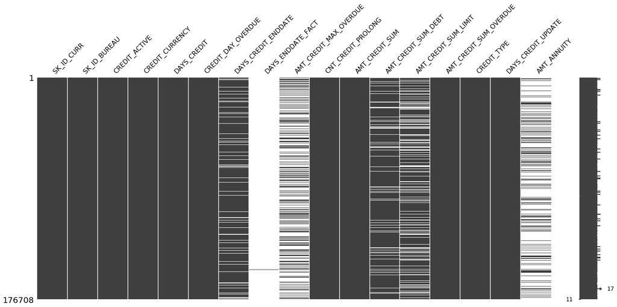

```python
msno.matrix(additional_df[additional_df.CREDIT_ACTIVE=='Active'])
```

```python
additional_df.DAYS_ENDDATE_FACT[additional_df.CREDIT_ACTIVE=='Active'] = 1
```

If I drop the two variables with more NaN's I get a much more consistent dataset

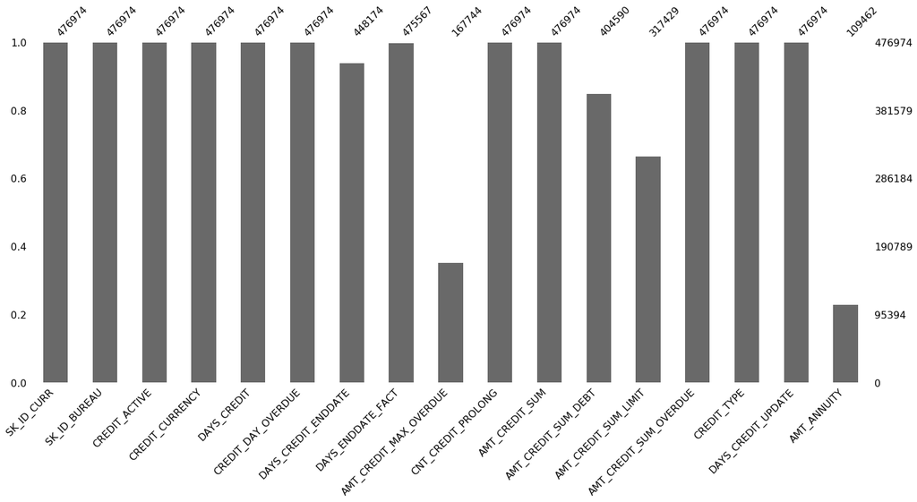

```python
msno.bar(additional_df)
```

```python
additional_df = additional_df.drop(columns = ['AMT_CREDIT_MAX_OVERDUE','AMT_ANNUITY']).dropna()
```

```python
additional_df.columns
```

```
Index(['SK_ID_CURR', 'SK_ID_BUREAU', 'CREDIT_ACTIVE', 'CREDIT_CURRENCY',
       'DAYS_CREDIT', 'CREDIT_DAY_OVERDUE', 'DAYS_CREDIT_ENDDATE',
       'DAYS_ENDDATE_FACT', 'CNT_CREDIT_PROLONG', 'AMT_CREDIT_SUM',
       'AMT_CREDIT_SUM_DEBT', 'AMT_CREDIT_SUM_LIMIT', 'AMT_CREDIT_SUM_OVERDUE',
       'CREDIT_TYPE', 'DAYS_CREDIT_UPDATE'],
      dtype='object')
```

```python
set(additional_df.columns).intersection(set(main_df.columns))
```

```
{'SK_ID_CURR'}
```

```python
additional_df.SK_ID_CURR.value_counts().sample(5)
```

```
286918    7
437605    1
355483    6
320487    1
261463    2
Name: SK_ID_CURR, dtype: int64
```

In order to use the additional information, I should calculate summary measures by SK_ID_CURR

I exclude SK_ID_BUREAU as it is an ID.

```python
additional_df = additional_df.loc[:, additional_df.columns != 'SK_ID_BUREAU']
```

I do an analysis over the categorical variables in order to understand if they can add valuable information

```python
additional_df_cat= additional_df.set_index('SK_ID_CURR').select_dtypes(['object'])
```

```python
additional_df_cat = additional_df_cat.join(main_df.loc[:, ['SK_ID_CURR','TARGET']].set_index('SK_ID_CURR'))
```

```python
additional_df_cat.sample(2)
```

| SK_ID_CURR | CREDIT_ACTIVE | CREDIT_CURRENCY | CREDIT_TYPE | TARGET |
| --- | --- | --- | --- | --- |
| 124528 | Closed | currency 1 | Credit card | 0.0 |
| 144843 | Closed | currency 1 | Consumer credit | 0.0 |

```python
additional_df_cat['TARGET'] =additional_df_cat['TARGET'].astype('category')
```

```python
additional_df_cat.groupby('TARGET').CREDIT_ACTIVE.value_counts(normalize=True)
```

```
TARGET  CREDIT_ACTIVE
0.0     Closed           0.614313
        Active           0.384567
        Sold             0.001116
        Bad debt         0.000004
1.0     Closed           0.544749
        Active           0.452858
        Sold             0.002393
Name: CREDIT_ACTIVE, dtype: float64
```

```python
additional_df_cat.groupby('TARGET').CREDIT_CURRENCY.value_counts(normalize=True)
```

```
TARGET  CREDIT_CURRENCY
0.0     currency 1         0.999645
        currency 2         0.000328
        currency 3         0.000018
        currency 4         0.000009
1.0     currency 1         1.000000
Name: CREDIT_CURRENCY, dtype: float64
```

```python
additional_df_cat.groupby('TARGET').CREDIT_TYPE.value_counts(normalize=True)
```

```
TARGET  CREDIT_TYPE
0.0     Consumer credit                           0.761632
        Credit card                               0.212575
        Mortgage                                  0.012491
        Car loan                                  0.010719
        Microloan                                 0.001566
        Unknown type of loan                      0.000531
        Another type of loan                      0.000337
        Loan for business development             0.000108
        Cash loan (non-earmarked)                 0.000031
        Loan for the purchase of equipment        0.000004
        Real estate loan                          0.000004
1.0     Consumer credit                           0.744323
        Credit card                               0.233129
        Mortgage                                  0.008774
        Car loan                                  0.007764
        Microloan                                 0.005424
        Another type of loan                      0.000266
        Unknown type of loan                      0.000266
        Loan for working capital replenishment    0.000053
Name: CREDIT_TYPE, dtype: float64
```

The distribution over the categories in this variables don't change with respect of the target (except maybe the active/closed status).

As there is no direct way to add this variables to the final dataset, such as summary measures, and from the distribution of the variables it doesn't emerge a clear patron (i.e. all the *car loans* have target=1) I decided to exclude this group of variables.

```python
additional_df= additional_df.select_dtypes(['number']).set_index('SK_ID_CURR').stack().reset_index()
additional_df.columns =['SK_ID_CURR', 'feature', 'value']
additional_df_summary = additional_df.groupby(['SK_ID_CURR','feature']).agg({'value':[np.nansum, np.nanmean, np.nanmedian, 'count']}).unstack()
additional_df_summary.columns =additional_df_summary.columns.map('_'.join)
```

```python
additional_df_summary.sample(2)
```

| SK_ID_CURR | value_nansum_AMT_CREDIT_SUM | value_nansum_AMT_CREDIT_SUM_DEBT | value_nansum_AMT_CREDIT_SUM_LIMIT | value_nansum_AMT_CREDIT_SUM_OVERDUE | value_nansum_CNT_CREDIT_PROLONG | value_nansum_CREDIT_DAY_OVERDUE | value_nansum_DAYS_CREDIT | value_nansum_DAYS_CREDIT_ENDDATE | value_nansum_DAYS_CREDIT_UPDATE | value_nansum_DAYS_ENDDATE_FACT | ... | value_count_AMT_CREDIT_SUM | value_count_AMT_CREDIT_SUM_DEBT | value_count_AMT_CREDIT_SUM_LIMIT | value_count_AMT_CREDIT_SUM_OVERDUE | value_count_CNT_CREDIT_PROLONG | value_count_CREDIT_DAY_OVERDUE | value_count_DAYS_CREDIT | value_count_DAYS_CREDIT_ENDDATE | value_count_DAYS_CREDIT_UPDATE | value_count_DAYS_ENDDATE_FACT |
| --- | --- | --- | --- | --- | --- | --- | --- | --- | --- | --- | --- | --- | --- | --- | --- | --- | --- | --- | --- | --- | --- |
| 448688 | 1943586.0 | 1322082.0 | 0.0 | 0.0 | 0.0 | 0.0 | -7152.0 | -3492.0 | -3916.0 | -5749.0 | ... | 4 | 4 | 4 | 4 | 4 | 4 | 4 | 4 | 4 | 4 |
| 163377 | 2574000.0 | 525555.0 | 0.0 | 0.0 | 0.0 | 0.0 | -2009.0 | 184.0 | -1110.0 | -544.0 | ... | 3 | 3 | 3 | 3 | 3 | 3 | 3 | 3 | 3 | 3 |

2 rows × 40 columns

```python
additional_df_summary.shape
```

```
(77959, 40)
```

```python
joined_df = main_df.set_index('SK_ID_CURR').join(additional_df_summary)
```

```python
print(joined_df.shape)

print(joined_df.dropna().shape)

print('the intersection between the two datasets is {}'.format(len( set(main_df.SK_ID_CURR).intersection(set(additional_df_summary.index)))))
```

```
(80000, 93)
(62348, 93)
the intersection between the two datasets is 62348
```

When I join the two datasets, new NaNs appears as not all the SK_ID_CURR from the main data exists in the cleaned additional dataset

I drop the data with NA. I could imput by the mean or a specific value, but the I consider that the amount of loss is manageable

```python
joined_df = joined_df.dropna()
```

I divide the features from the target, and split in train and test

```python
X = joined_df.loc[:, joined_df.columns != 'TARGET']
```

I need to One Hot encode categorical variables

```python
categorical_X = X.select_dtypes(['object'])
numeric_X = X.select_dtypes(['number'])
le = LabelEncoder()
categorical_X= categorical_X.apply(LabelEncoder().fit_transform)
ohe = OneHotEncoder(sparse=False,handle_unknown='ignore')
categorical_X = ohe.fit_transform(categorical_X)
numeric_X = np.array(numeric_X)

X = np.concatenate((numeric_X,categorical_X),axis=1)
```

```python
df = pd.DataFrame(X)
```

```python
df=df.assign(target=joined_df.TARGET.values)
```

```python
df_train, df_test = train_test_split(df,random_state=12,test_size=.1)
df_train, df_validation = train_test_split(df_train,random_state=12,test_size=.1)
```

## Target balance

```python
target_count = df_train.target.value_counts()
```

```
Class 0: 46565
Class 1: 3936
Proportion: 11.83 : 1
```

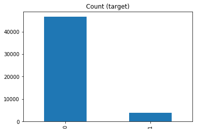

```python
print('Class 0:', target_count[0])
print('Class 1:', target_count[1])
print('Proportion:', round(target_count[0] / target_count[1], 2), ': 1')

target_count.plot(kind='bar', title='Count (target)');
```

The target is heavily unbalanced. Here is important to recognize the problem objective, because this determines how to proceed.

The Documentation states that the goal is to 'predict whether to offer loans to clients' but we do not know the relative costs of **false positives** and **false negatives**.

I will make the following **assumption**: The main goal is to predict well the **positive** class, because it imply more costs. i.e. the target is the defaulted loans, and hence a correct prediction of this is more valuable than a correct prediction of the non-defaulted loans

Because of the previous assumption I will *resample* the dataset in order to balance the classes. In order to avoid loosing more data, I decided to use **random over-sampling**

```python
# Class count
count_class_0, count_class_1 = target_count
```

```python
# Divide by class
df_class_0 = df_train[df_train['target'] == 0]
df_class_1 = df_train[df_train['target'] == 1]
```

```
Random over-sampling:
1    46565
0    46565
Name: target, dtype: int64
```

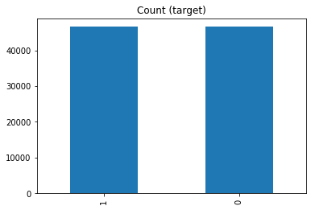

```python
df_class_1_over = df_class_1.sample(count_class_0, replace=True)
df_train_resampled = pd.concat([df_class_0, df_class_1_over], axis=0)

print('Random over-sampling:')
print(df_train_resampled.target.value_counts())

df_train_resampled.target.value_counts().plot(kind='bar', title='Count (target)');
```

```python
X_train = df_train_resampled.drop('target', axis=1).values
y_train = df_train_resampled.target.values

X_val = df_validation.drop('target', axis=1).values
y_val = df_validation.target.values

X_test = df_test.drop('target', axis=1).values
y_test = df_test.target.values
```

### Model fitting

I will try three diferent models, from the simplest to the most advanced techinques:

- Logistic regression
- Naive Bayes
- Gradient Boosting Machine

I decided to use a Gradient Boosting Machine (from the same family of models of the famous XGBOOST) and not a Deep Learning approach because of the input data. In my experience structured data is best fitted by ensambles of trees, while is better to approach unstructured problems(image, audio, etc) with neural networks

#### Logistic regression

```python
from sklearn.linear_model import LogisticRegression
```

```python
logit = LogisticRegression()
logit.fit(X_train,y_train)
```

```
LogisticRegression(C=1.0, class_weight=None, dual=False, fit_intercept=True,
          intercept_scaling=1, max_iter=100, multi_class='warn',
          n_jobs=None, penalty='l2', random_state=None, solver='warn',
          tol=0.0001, verbose=0, warm_start=False)
```

```python
logit.score(X_val,y_val)
```

```
0.5980042765502495
```

```python
y_pred=logit.predict(X_val)
print(confusion_matrix(y_val, y_pred))
print(classification_report(y_val, y_pred))
```

```
[[3114 2046]
 [ 210  242]]
              precision    recall  f1-score   support

           0       0.94      0.60      0.73      5160
           1       0.11      0.54      0.18       452

   micro avg       0.60      0.60      0.60      5612
   macro avg       0.52      0.57      0.46      5612
weighted avg       0.87      0.60      0.69      5612
```

#### Naive Bayes

```python
from sklearn.naive_bayes import GaussianNB
```

```python
nb = GaussianNB()
nb.fit(X_train, y_train)
```

```
GaussianNB(priors=None, var_smoothing=1e-09)
```

```python
nb.score(X_val,y_val)
```

```
0.5181753385602281
```

```python
y_pred=nb.predict(X_val)
print(confusion_matrix(y_val, y_pred))
print(classification_report(y_val, y_pred))
```

```
[[2609 2551]
 [ 153  299]]
              precision    recall  f1-score   support

           0       0.94      0.51      0.66      5160
           1       0.10      0.66      0.18       452

   micro avg       0.52      0.52      0.52      5612
   macro avg       0.52      0.58      0.42      5612
weighted avg       0.88      0.52      0.62      5612
```

### Gradient Bosting Machine

```python
bstmodel = GradientBoostingClassifier()
bstmodel.fit(X_train,y_train)
```

```
GradientBoostingClassifier(criterion='friedman_mse', init=None,
              learning_rate=0.1, loss='deviance', max_depth=3,
              max_features=None, max_leaf_nodes=None,
              min_impurity_decrease=0.0, min_impurity_split=None,
              min_samples_leaf=1, min_samples_split=2,
              min_weight_fraction_leaf=0.0, n_estimators=100,
              n_iter_no_change=None, presort='auto', random_state=None,
              subsample=1.0, tol=0.0001, validation_fraction=0.1,
              verbose=0, warm_start=False)
```

```python
bstmodel.score(X_val,y_val)
```

```
0.6534212401995724
```

```python
y_pred=bstmodel.predict(X_val)
print(confusion_matrix(y_val, y_pred))
print(classification_report(y_val, y_pred))
```

```
[[3394 1766]
 [ 179  273]]
              precision    recall  f1-score   support

           0       0.95      0.66      0.78      5160
           1       0.13      0.60      0.22       452

   micro avg       0.65      0.65      0.65      5612
   macro avg       0.54      0.63      0.50      5612
weighted avg       0.88      0.65      0.73      5612
```

there is an important trade-off between the recall of the two classes. In order to optimize this, it would be necessary more information of the costs involved in the different types of mistakes. This would modify both the resampling and the model selection (between Naive Bayes and the Gradient Boosting Machine)

### Final Model

Based on the results on the validation set, I choose the Gradient boosting machine model, and test it over the test set

```python
bstmodel.score(X_test,y_test)
```

```
0.6559743384121892
```

```python
y_pred=bstmodel.predict(X_test)
print(confusion_matrix(y_test, y_pred))
print(classification_report(y_test, y_pred))
```

```
[[3798 1941]
 [ 204  292]]
              precision    recall  f1-score   support

           0       0.95      0.66      0.78      5739
           1       0.13      0.59      0.21       496

   micro avg       0.66      0.66      0.66      6235
   macro avg       0.54      0.63      0.50      6235
weighted avg       0.88      0.66      0.73      6235
```

## Final notes

This workflow could be enhanced by using a pipeline from *sklearn.pipeline* and cross-validation for the fine tuning of the final model, and in order to choose if the missing data should be excluded (like I did) or imputed, and how (mean, 0, or maybe some imputation algorithm).

Given the limited time for this excercise and that the Boosting Machine default parameters are known to be robust, I decided to skip this part. The decistion of excluding the missing values was supported with the validation set, but is not showed for the clarity of the code